# Capitalism, Free Markets, & Socialism

DRAFT as of: 2025-08-18

# Intro

How are capitalism and free markets related? Does supporting Medicare-for-all make you a socialist? Let’s talk about these commonly misunderstood theories of resource allocation. We will review the basics before will explain how capitalists have conflated capitalism with free market theory at the detriment of free markets by taking a look at several markets in the US economy.

# Plotting supply and demand

The supply and demand graph serves as a visual representation of classical economic thinking. Students encounter it on the first day of any economics course and it as it the root of the assumed efficiency of real-world markets. It looks something like Figure 1.

Figure 1: The typical supply and demand graph

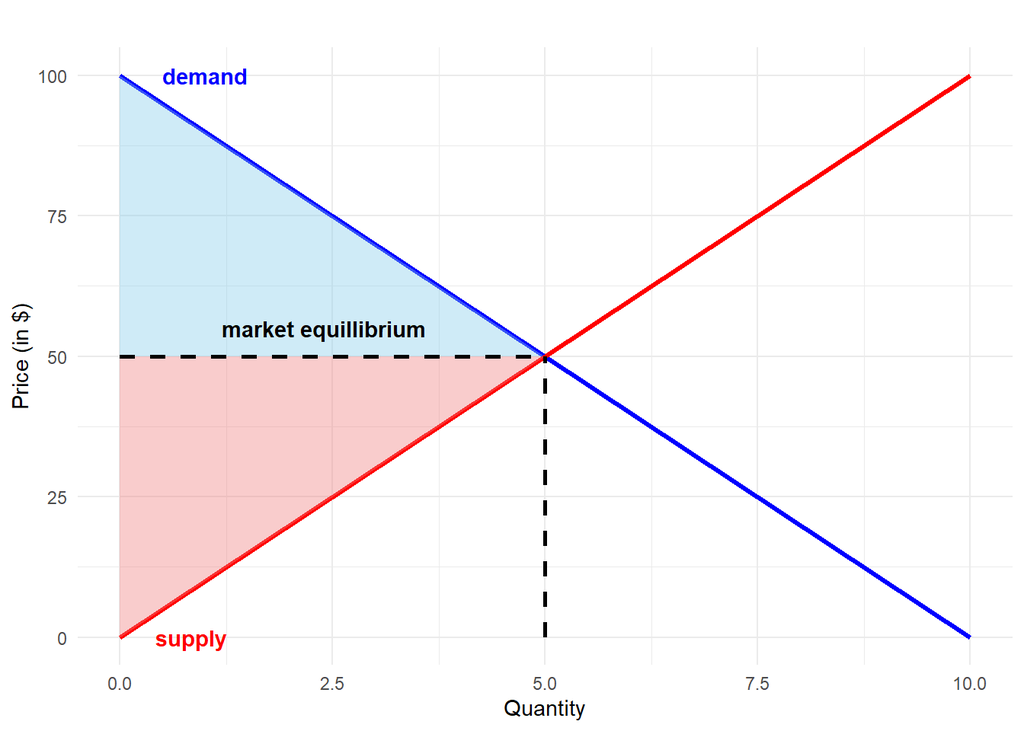

In this common example, the demand curve is illustrated in blue and the supply curve is illustrated in red. Consumer and producer surplus are represented by the sky blue and pink shaded areas, respectively. In this scenario, five units are sold at $50 each and both the consumer and producer see healthy and equitable surpluses. Everyone walks away better off from the exchange.

Before we move on, we need to address the underlying assumption of perfect competition that prevents this level of efficiency from being realized in the world. This assumption removes the need to distinguish between marginal revenue and the demand curve because firms in competitive markets are considered price-takers. In reality, profit-maximizing firms set their prices where marginal revenue equals marginal costs. A more realistic market graph would look closer to Figure 2.

Figure 2: A more realistic market graph

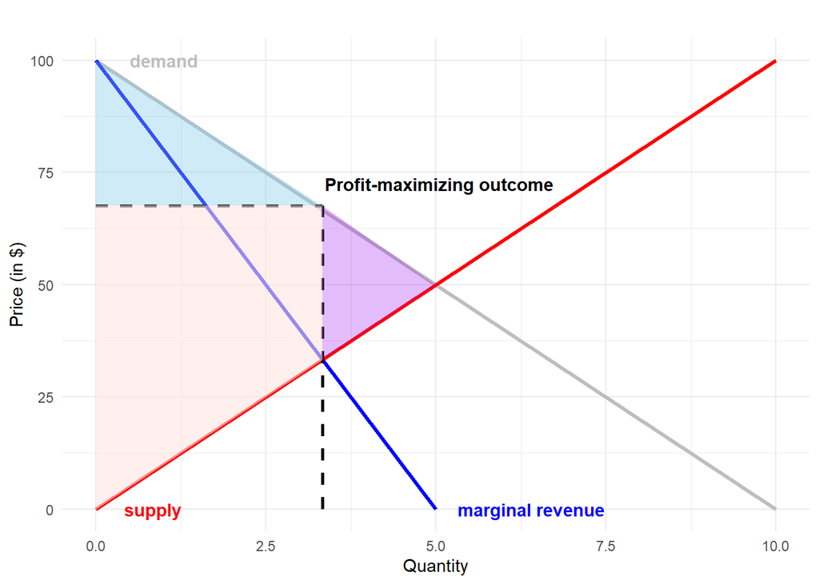

Figure 2 more aptly illustrates a typical real world market where firms in increasingly consolidated markets set their prices to maximize profits. The resulting market inefficiency is expressed in deadweight loss. Ultimately, these sellers are sacrificing consumer surplus and overall market efficiency for increased producer surplus. This example gets at the relationship between market power and market efficiency. There are many other market factors that produce inefficiencies to varying degrees. These are often referred to as market failures because they prevent a market from achieving market equilibrium.

# Market failures

Market failures cause inefficient market that fail to produce an optimal quantity of goods or services at fair prices. We will get into market failures in detail, but the table here describes the main types of market failures we will discuss.

[output not shown]

### Market failures in the US economy

- Elections and governance
- Healthcare (medical care and pharmaceuticals)
- Education
- Energy
- Food
- Media

# Why capitalists love market failures

# How “socialist” policies bolster free markets